# Cluster analysis

Finding groups in data

Dr Massimiliano Canzi

# Cluster analysis

`Did you know:` Koshik, an Asian elephant in a zoo in South Korea, imitates five Korean words, such as *annyong* ‘hello’ and *anja* ‘sit down’. To match human formants, he puts the tip of his trunk in his mouth.

*Source: Stoeger et al. (2012), Current Biology*

## Where we are

Factor analysis grouped the variables: which questionnaire items or linguistic features go together. Cluster analysis groups the observations, such as tokens, speakers, texts or dialect locations, so that observations in the same group are similar and observations in different groups are not.

There is no outcome to predict. The data have no labels for the groups, and the method has to find them: this is unsupervised learning. This lecture explains how clustering works and how to check its results; lecture 11 clusters the web registers from lecture 9.

## Today

1. Distances
2. k-means
3. Hierarchical and model-based clustering
4. Choosing and checking clusters

## The data

`korean_stops` from {simling}: word-initial lenis, tense and aspirated stops from 20 older and 20 younger speakers of Seoul Korean, with the VOT and the f0 of the following vowel.

```r
ks <- korean_stops |>
  mutate(f0_st = 12 * log2(f0 / ave(f0, speaker)))
ks
```

```
# A tibble: 1,440 × 9
  speaker generation gender stop      place     rep   vot    f0  f0_st
  <fct>   <fct>      <fct>  <fct>     <fct>   <int> <dbl> <dbl>  <dbl>
1 S01     older      female aspirated coronal     1    99   234  3.12
2 S01     older      female aspirated coronal     2    58   230  2.82
3 S01     older      female aspirated coronal     3   113   214  1.57
4 S01     older      female aspirated coronal     4    81   194 -0.126
# ℹ 1,436 more rows
```

`f0_st` is f0 in semitones relative to each speaker’s mean, so that women and men are on the same scale. `?korean_stops` gives the true model.

## A sound change in progress

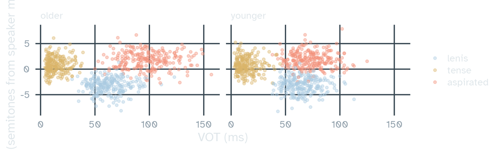

Older speakers keep lenis and aspirated stops apart by VOT and by f0. In younger speakers, aspirated VOT has shortened, so the two overlap in VOT and f0 keeps them apart (Silva, 2006). Today we hide the colours and ask whether a clustering method finds the three stops.

# Distances

`Did you know:` Asian elephants make infrasonic calls, with fundamental frequencies down to about 14 Hz, below the range of human hearing.

*Source: Payne, Langbauer & Thomas (1986), Behavioral Ecology and Sociobiology*

## Distances between observations

Every clustering method starts from a distance between observations. With two measures, the usual Euclidean distance is the length of the straight line between two points in the plot:

d = √((vot₁ − vot₂)² + (f0₁ − f0₂)²)

With more measures, the formula adds one squared difference per measure. `dist()` computes the distances between all pairs of rows.

## Units decide the distance

```r
c(vot = sd(ks$vot), f0_st = sd(ks$f0_st))
```

```
      vot     f0_st
33.722355  2.652173
```

VOT varies by tens of milliseconds, f0 by a few semitones. In the raw units, a difference of 10 ms counts as much as a difference of 10 semitones, so the distance is almost all VOT. Standardising each measure with `scale()` gives both a standard deviation of 1 and the same weight.

## Raw or standardised?

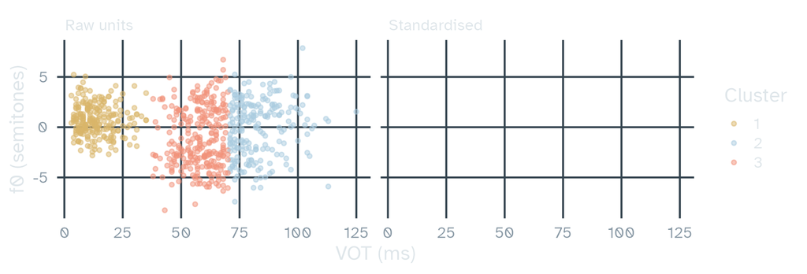

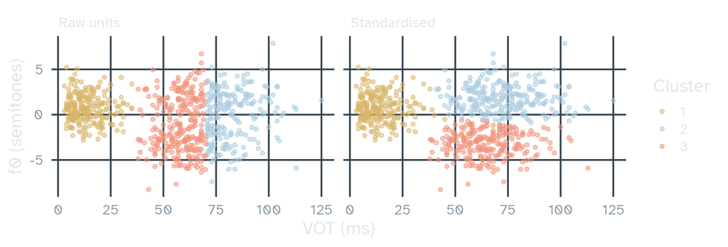

Younger speakers, three clusters each. On raw units, the clusters cut along VOT and split the lenis and aspirated stops in the middle. Standardised, f0 counts too, and the clusters follow the stops.

## Choosing and transforming the variables

The choice of measures and their transformation decides what “similar” means, before any algorithm runs.

```r
set.seed(1)
km_hz <- kmeans(scale(younger[c("vot", "f0")]), centers = 2, nstart = 25)
table(younger$gender, km_hz$cluster)
```

```
           1   2
  female 124 236
  male   117 243
```

# k-means

`Did you know:` Mlaika, an adolescent African elephant in Kenya, imitated the sound of trucks. Another elephant, kept with Asian elephants in a Swiss zoo, imitated their chirping calls.

*Source: Poole et al. (2005), Nature*

## The algorithm

k-means splits the data into a number of clusters `k` that you choose in advance.

1. Place `k` cluster centres at random
2. Assign each observation to its nearest centre
3. Move each centre to the mean of the observations assigned to it
4. Repeat steps 2 and 3 until no observation changes cluster

Each step lowers the within-cluster sum of squares: the squared distances of the observations from their centres, added up.

## Three steps

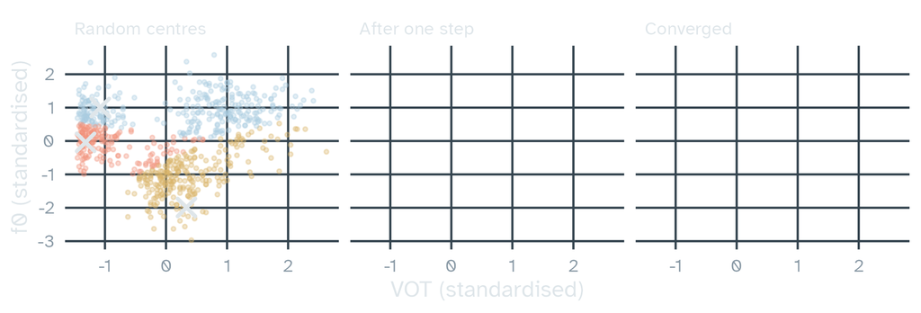

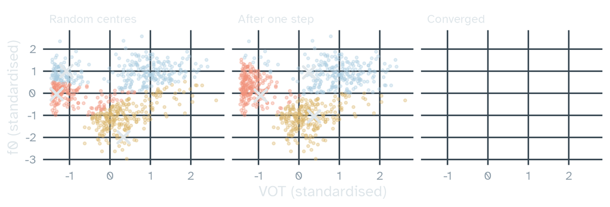

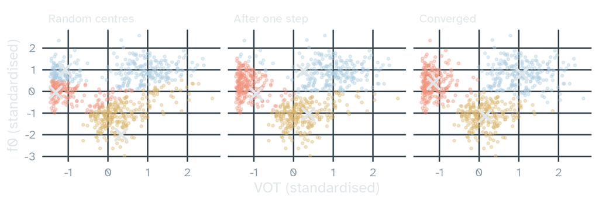

Older speakers. The crosses are the centres; each point takes the colour of its nearest centre.

## `kmeans()`

```r
X_old <- scale(older[c("vot", "f0_st")])
set.seed(1)
km <- kmeans(X_old, centers = 3, nstart = 25)
km$size
```

```
[1] 245 247 228
```

```r
table(older$stop, km$cluster)
```

```
              1   2   3
  lenis       3 234   3
  tense     239   1   0
  aspirated   3  12 225
```

`nstart = 25` runs the algorithm from 25 random starts and keeps the best solution. The cluster numbers are arbitrary, so compare the table by its rows: almost every stop falls into one cluster of its own.

## Back to the original units

```r
older |>
  mutate(cluster = km$cluster) |>
  summarise(n = n(), vot = mean(vot), f0_st = mean(f0_st), .by = cluster) |>
  arrange(vot)
```

```
# A tibble: 3 × 4
  cluster     n   vot  f0_st
    <int> <int> <dbl>  <dbl>
1       1   245  15.2  0.822
2       2   247  64.2 -3.22
3       3   228  98.7  1.97
```

`km$centers` is on the standardised scale. To describe the clusters, compute their means in the original units.

## What k-means assumes

- Clusters are round and about the same size, because every observation goes to its nearest centre
- Every observation belongs to exactly one cluster, including outliers and observations halfway between two clusters
- The result can depend on the starting centres, which is why `nstart` should be well above 1
- `k` comes from you, and k-means will find that many clusters in any data

k-medoids (`cluster::pam()`) uses actual observations as centres and works with any distance, which makes it less sensitive to outliers (Kaufman & Rousseeuw, 1990).

# Hierarchical and model-based clustering

`Did you know:` elephant rumbles also travel through the ground as seismic waves. In experiments, elephants detected played-back calls through the ground alone and responded to them.

*Source: O’Connell-Rodwell (2007), Physiology*

## Merging step by step

Agglomerative hierarchical clustering needs no `k` in advance. It starts with every observation in a cluster of its own, and at each step merges the two closest clusters, until only one is left.

The linkage method decides how close two clusters are:

- single linkage takes their two closest members, complete linkage their two farthest members, and average linkage the mean of all pairs
- Ward’s method merges the two clusters that increase the within-cluster sum of squares least, the quantity k-means minimises (Ward, 1963)

## The dendrogram

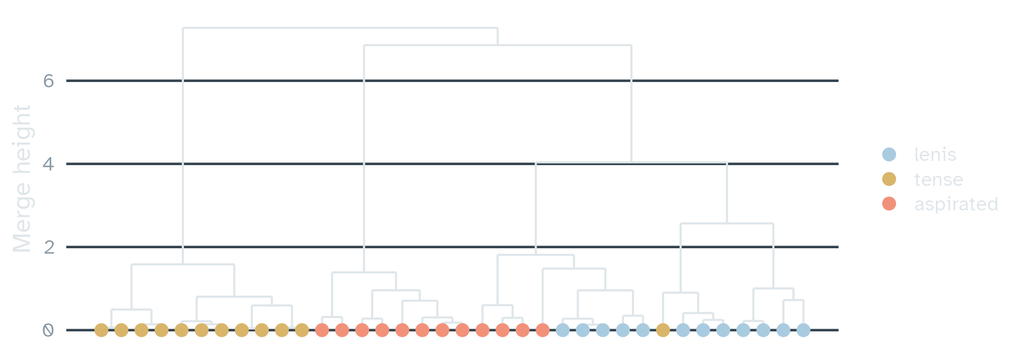

36 tokens from older speakers, 12 of each stop. The height of a merge is the distance between the two clusters it joins. Cutting the tree at one height gives a clustering.

## `hclust()` and `cutree()`

```r
hc <- hclust(dist(X_old), method = "ward.D2")
table(older$stop, cutree(hc, k = 3))
```

```
              1   2   3
  lenis       1 237   2
  tense       0   0 240
  aspirated 198  42   0
```

`dist()` computes the distances, `hclust()` merges, and `cutree()` cuts the tree into `k` clusters, or at a height `h`. `"ward.D2"` is Ward’s method on Euclidean distances. One tree gives the clusterings for every `k` at once.

## Linkage matters

```r
X_young <- scale(younger[c("vot", "f0_st")])
d_young <- dist(X_young)
map(c("single", "average", "ward.D2"), \(m) {
  cl <- cutree(hclust(d_young, method = m), k = 3)
  tibble(method = m, sizes = paste(sort(table(cl), decreasing = TRUE), collapse = ", "))
}) |> list_rbind()
```

```
# A tibble: 3 × 2
  method  sizes
  <chr>   <chr>
1 single  718, 1, 1
2 average 488, 231, 1
3 ward.D2 259, 231, 230
```

On the younger speakers, single linkage puts almost every token into one cluster. It chains: two groups that touch at one point merge early. Average linkage keeps the tense stops apart but merges lenis and aspirated, and leaves one token as a cluster of its own. Ward’s method gives three clusters of similar size, like k-means.

## Model-based clustering

A Gaussian mixture model treats the data as a mix of normal distributions, one per cluster, each with its own centre, spread and orientation. Clusters can be elliptical and differ in size, and every observation gets a probability of belonging to each cluster (Fraley & Raftery, 2002).

`{mclust}` fits mixtures with different numbers of components and different shapes, and chooses among them by BIC, which rewards fit and penalises the number of parameters (Scrucca et al., 2016).

## `Mclust()`

```r
mc_raw <- mclust::Mclust(X_old, G = 1:6, verbose = FALSE)
mc_raw$G
```

```
[1] 4
```

```r
table(older$stop, mc_raw$classification)
```

```
              1   2   3   4
  lenis       7 232   0   1
  tense       0   1 115 124
  aspirated 234   6   0   0
```

BIC prefers four components, and the tense stops take two of them. Their VOT is skewed to the right, and one normal distribution does not fit it.

## Log VOT

```r
X_log <- scale(cbind(log_vot = log(older$vot), f0_st = older$f0_st))
mc_log <- mclust::Mclust(X_log, G = 1:6, verbose = FALSE)
mc_log$G
```

```
[1] 3
```

```r
table(older$stop, mc_log$classification)
```

```
              1   2   3
  lenis       4 234   2
  tense       0   0 240
  aspirated 230   9   1
```

On the log scale, the tense stops are roughly normal. BIC chooses three components, and they match the stops. A component is one normal distribution, so a cluster with another shape can need several.

# Choosing and checking clusters

`Did you know:` wild African elephants in Kenya address each other with name-like calls. They responded more strongly to playbacks of calls that had first been addressed to them than to calls addressed to other elephants.

*Source: Pardo et al. (2024), Nature Ecology & Evolution*

## The elbow

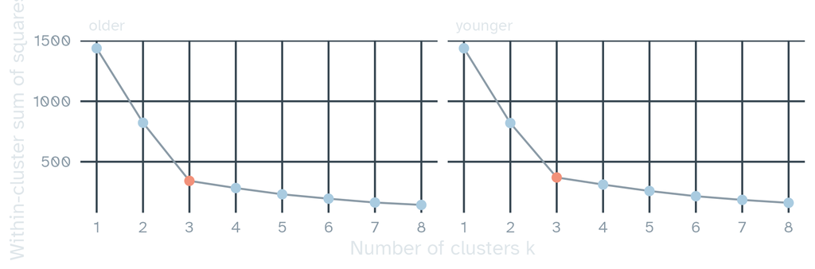

More clusters always lower the within-cluster sum of squares. Look for the elbow, where adding a cluster stops helping much. Here it is at 3 in both generations, though elbows are often less clear.

## Silhouettes

For each observation, the silhouette width compares `a`, its mean distance to the other members of its own cluster, with `b`, its mean distance to the members of the nearest other cluster (Rousseeuw, 1987):

s = (b − a) / max(a, b)

- `s` close to 1: the observation sits well inside its cluster
- `s` around 0: it lies between two clusters
- `s` below 0: it is closer to another cluster than to its own

## Choosing k with silhouettes

```r
avg_sil <- function(X, k) {
  set.seed(1)
  cl <- kmeans(X, centers = k, nstart = 25)$cluster
  mean(silhouette(cl, dist(X))[, "sil_width"])
}
tibble(k = 2:6,
       older = map_dbl(k, \(k) avg_sil(X_old, k)),
       younger = map_dbl(k, \(k) avg_sil(X_young, k)))
```

```
# A tibble: 5 × 3
      k older younger
  <int> <dbl>   <dbl>
1     2 0.432   0.435
2     3 0.566   0.537
3     4 0.481   0.443
4     5 0.427   0.384
# ℹ 1 more row
```

The average silhouette width is highest at k = 3 in both generations. `silhouette()` comes from `{cluster}`, which is installed with R.

## Clustering random noise

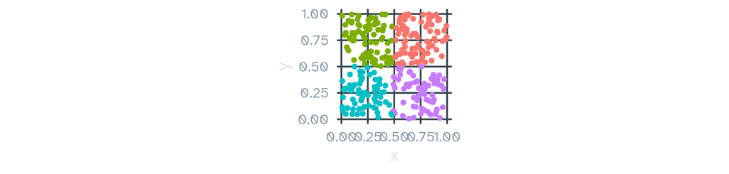

```r
set.seed(3)
noise <- tibble(x = runif(300), y = runif(300))
set.seed(1)
km_noise <- kmeans(noise, centers = 4, nstart = 25)
ggplot(mutate(noise, cluster = factor(km_noise$cluster)), aes(x, y, colour = cluster)) +
  geom_point(size = 1.6, show.legend = FALSE) + coord_equal()
```

Uniform noise, with no groups at all, cut into four tidy clusters. Its average silhouette width is 0.45.

## How strong is the structure?

Kaufman and Rousseeuw (1990) suggested reading the average silhouette width like this:

| Average silhouette width | Structure |
| --- | --- |
| 0.71 to 1 | strong |
| 0.51 to 0.70 | reasonable |
| 0.26 to 0.50 | weak, could be artificial |
| 0.25 or less | no substantial structure |

The Korean stops reach 0.57 (older) and 0.54 (younger): reasonable. The noise, at 0.45, would have counted as weak structure.

## Comparing with known groups

Here we know the stops, so we can check the clusters against them. In a real application of clustering we usually do not, but often there is a variable to compare with, such as a register, a region or a speaker group.

- A cross-table of clusters and groups shows which groups end up together
- The adjusted Rand index sums the table up in one number: 1 when the two groupings are identical, around 0 for chance agreement (Hubert & Arabie, 1985). `mclust::adjustedRandIndex()` computes it
- A cluster that matches no known group may be worth a look, or may be an artefact of the choices made

## Two generations

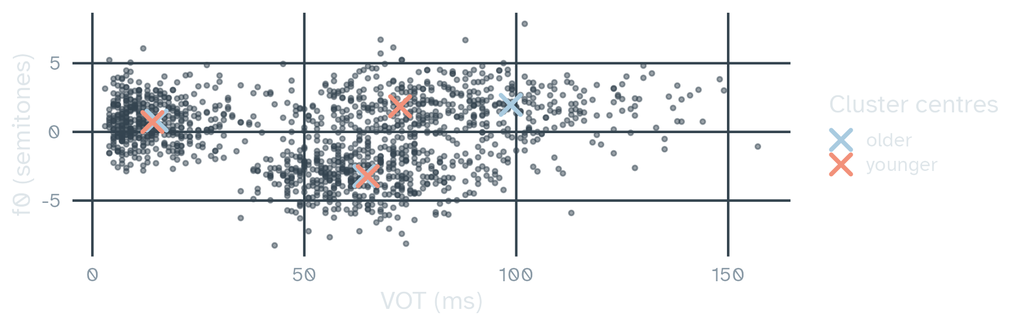

Both generations have three clusters, but the centre with high f0 and long VOT has moved to a shorter VOT in the younger speakers, as in Silva’s (2006) data.

## Tokens or speakers?

Our tokens are not independent: each speaker contributes 36, and tokens of one speaker resemble each other.

- Clustering tokens describes the categories in the data, but how well a clustering holds up says little about new speakers
- To group speakers, such as dialect speakers by their vowel systems, cluster one row per speaker, for example speaker means or model estimates
- Check stability: cluster random halves of the speakers, or bootstrap samples, and see whether the same clusters come back

## Reporting

Report the variables and how you transformed them, the distance, the method and its settings, how you chose `k`, and how you checked the clusters.

## Summary

- Cluster analysis groups observations without labels. The variables, their transformation and the distance decide what counts as similar
- Standardise measures on different scales, and normalise away groups you are not looking for
- k-means needs `k` in advance and assumes round clusters; use many random starts
- Hierarchical clustering builds a tree for every `k`; the linkage method changes the result, and Ward’s method behaves like k-means
- Gaussian mixtures allow elliptical clusters and choose `k` by BIC, but each component must be roughly normal
- Every method finds clusters, even in noise: choose `k` with the elbow and silhouettes, compare with known groups and check stability

## References

- Fraley, C., & Raftery, A. E. (2002). Model-based clustering, discriminant analysis, and density estimation. *Journal of the American Statistical Association*, 97(458), 611–631. https://doi.org/10.1198/016214502760047131
- Hubert, L., & Arabie, P. (1985). Comparing partitions. *Journal of Classification*, 2(1), 193–218. https://doi.org/10.1007/BF01908075
- James, G., Witten, D., Hastie, T., & Tibshirani, R. (2021). *An introduction to statistical learning: With applications in R* (2nd ed.). Springer. Chapter 12. https://www.statlearning.com https://doi.org/10.1007/978-1-0716-1418-1
- Kaufman, L., & Rousseeuw, P. J. (1990). *Finding groups in data: An introduction to cluster analysis*. Wiley. https://doi.org/10.1002/9780470316801

## References (continued)

- Rousseeuw, P. J. (1987). Silhouettes: A graphical aid to the interpretation and validation of cluster analysis. *Journal of Computational and Applied Mathematics*, 20, 53–65. https://doi.org/10.1016/0377-0427(87)90125-7
- Scrucca, L., Fop, M., Murphy, T. B., & Raftery, A. E. (2016). mclust 5: Clustering, classification and density estimation using Gaussian finite mixture models. *The R Journal*, 8(1), 289–317. https://doi.org/10.32614/RJ-2016-021
- Silva, D. J. (2006). Acoustic evidence for the emergence of tonal contrast in contemporary Korean. *Phonology*, 23(2), 287–308. https://doi.org/10.1017/S0952675706000911
- Ward, J. H. (1963). Hierarchical grouping to optimize an objective function. *Journal of the American Statistical Association*, 58(301), 236–244. https://doi.org/10.1080/01621459.1963.10500845

## Sources of the animal facts

- O’Connell-Rodwell, C. E. (2007). Keeping an “ear” to the ground: Seismic communication in elephants. *Physiology*, 22(4), 287–294. https://doi.org/10.1152/physiol.00008.2007
- Pardo, M. A., Fristrup, K., Lolchuragi, D. S., Poole, J. H., Granli, P., Moss, C., Douglas-Hamilton, I., & Wittemyer, G. (2024). African elephants address one another with individually specific name-like calls. *Nature Ecology & Evolution*, 8(7), 1353–1364. https://doi.org/10.1038/s41559-024-02420-w
- Payne, K. B., Langbauer, W. R., & Thomas, E. M. (1986). Infrasonic calls of the Asian elephant (*Elephas maximus*). *Behavioral Ecology and Sociobiology*, 18(4), 297–301. https://doi.org/10.1007/BF00300007
- Poole, J. H., Tyack, P. L., Stoeger-Horwath, A. S., & Watwood, S. (2005). Elephants are capable of vocal learning. *Nature*, 434, 455–456. https://doi.org/10.1038/434455a
- Stoeger, A. S., Mietchen, D., Oh, S., de Silva, S., Herbst, C. T., Kwon, S., & Fitch, W. T. (2012). An Asian elephant imitates human speech. *Current Biology*, 22(22), 2144–2148. https://doi.org/10.1016/j.cub.2012.09.022

## Slides and code

[figure not shown]

These slides

mcanzi.de/advanced_statistics/10_cluster_analysis.html

Code and all lectures

github.com/mcanzi/advanced_statistics